# Modeling the spatial spread of emerging infectious diseases in highly heterogeneous environments

John M. Drake

Odum School of Ecology, University of Georgia

Ecological Society of America Annual Meeting

Salt Lake City, UT

July 29, 2026

West Nile virus, 1999–2005

## Too coarse to explain, or too costly to fit

Heterogeneity is the rule — climate, land use, hosts, and vectors all change from county to county. Three ways we usually model spread through it:

- **Diffusion** — traveling waves on a homogeneous plane; the heterogeneity is washed out.
- **Gravity models** — fit well, but phenomenological: one exponent conflates production, movement, and establishment.
- **Coupled metapopulation ODEs** — full dynamics at every location, but overparameterized — fittable only with rich panel data (Li, Ionides, King, Pascual & Ning 2024).

**But we rarely have panel data.** What we usually *do* have is **first-report data** — the first WNV case in a county, the first mussel in a lake. We want a model we can fit to *that*.

## What we infer is which landscape features drive invasion — and how

The spatial units are **handed to us by the data** — counties for WNV, lakes for mussels. Spatial resolution isn’t something we estimate.

What *is* unknown: **which features of the landscape shape invasion, and through what functional form.**

So we want a framework where each candidate mechanism can be **added parametrically** — every feature enters as estimable terms we can test.

# A framework for spread in heterogeneous landscapes

## Spread decomposes into production, movement, and observation

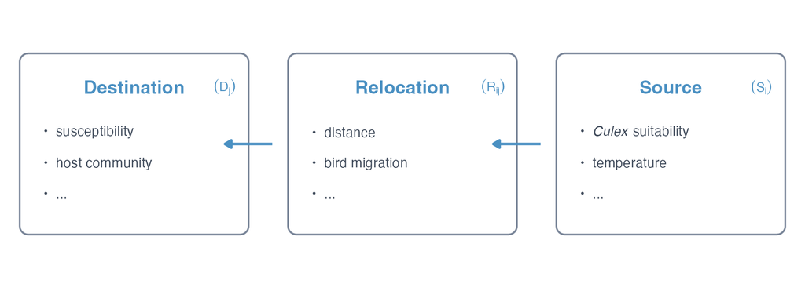

Every invasion event decomposes into a source that produces infection, a redistribution process that carries it across space, and a destination that receives it.

## Each process enters at its own biological scale

For an uninfected county $j$ at week $t$, the **force of infection** sums over all currently infected sources $i$:

$$\lambda_{ij,t} = \underbrace{K\vphantom{S_{i,t}}}_{\text{scale}}\;\underbrace{D_{j,t}}_{\text{destination}}\;\underbrace{R_{ij,t}}_{\text{redistribution}}\;\underbrace{S_{i,t}}_{\text{source}}
\qquad \Lambda_{j,t} = \sum_{i \,\in\, \text{infected}} \lambda_{ij,t}$$

- Each component is **parameterized independently**
- Covariates enter at the **appropriate mechanism**
- The **classical gravity model is a special case**

## A likelihood turns the framework into inference

Each week, every at-risk county experiences infection (or invasion) as a **Poisson process** with rate $\Lambda_{j,t}$:

$$-\log \mathcal{L} = \sum_{t}\left[\; -\!\!\sum_{j \,\in\, \text{new}(t)} \log\!\left(1 - e^{-\Lambda_{j,t}}\right) \;+\!\! \sum_{j \,\text{ remains at risk at } t} \Lambda_{j,t}\;\right]$$

Fit **directly to surveillance data** by maximum likelihood → parameter estimates, standard errors, and **formal model comparison (AIC)**.

# West Nile virus in North America

## Macroscopic patterns

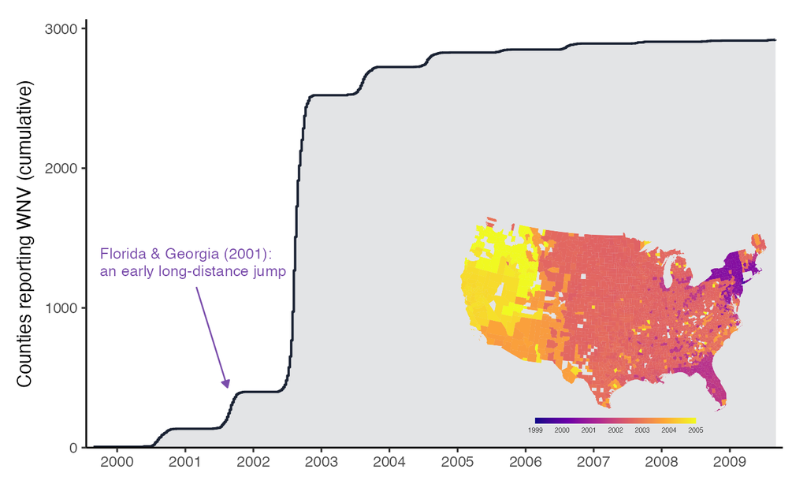

Cumulative U.S. counties reporting West Nile virus, 1999–2009 (inset: year of first report): fast continental spread, seasonal steps, and an early long-distance jump to Florida and Georgia in 2001.

## Baseline model overpredicts the early part of the invasion and underpredicts the late part of the invasion

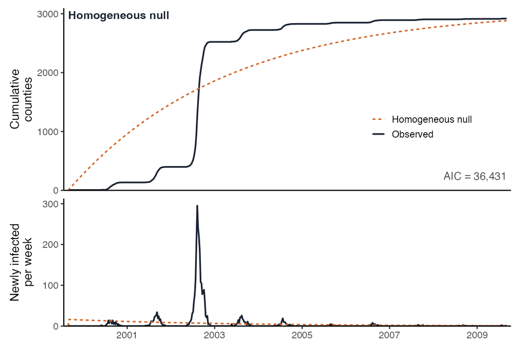

A homogeneous model — no landscape heterogeneity, no seasonality, one constant rate — spreads the invasion evenly across the decade, overpredicting the early years and underpredicting the sharp increase in 2002.

## Hypothesis 1: Heterogeneity in *Culex* habitat

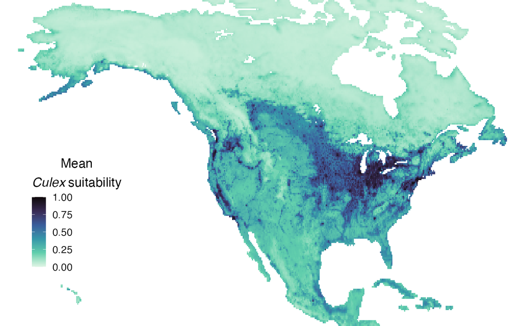

Modeled habitat suitability for the three predominant *Culex* vectors (Gorris et al. 2021), averaged to a single surface and aggregated by county — highest across the upper Midwest and California’s Central Valley.

## Space and *Culex* habitat: a big gain, but the timing is still wrong

$$\lambda_{ij,t}=K\,(\textit{Culex}_i)^{e^{s_1}}\,(\textit{Culex}_j)^{e^{d_1}}\,\textit{dist}_{ij}^{\,-e^{r_1}},\qquad K=10^{\alpha}$$

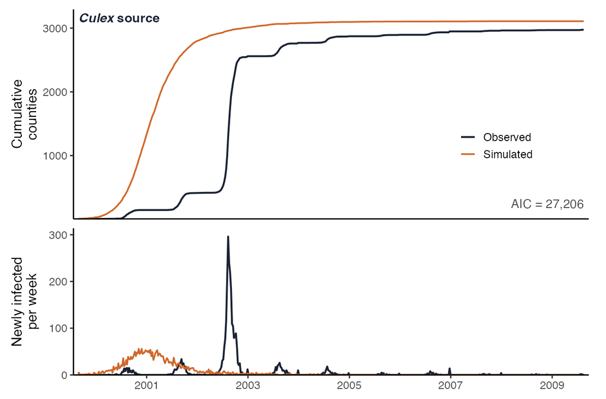

A power-law distance kernel plus *Culex* suitability at the source drops AIC from 36,431 to 27,206 — a large gain — yet the simulated invasion still runs ahead of the real one and climbs too smoothly.

## *Culex* habitat at the destination adds nothing

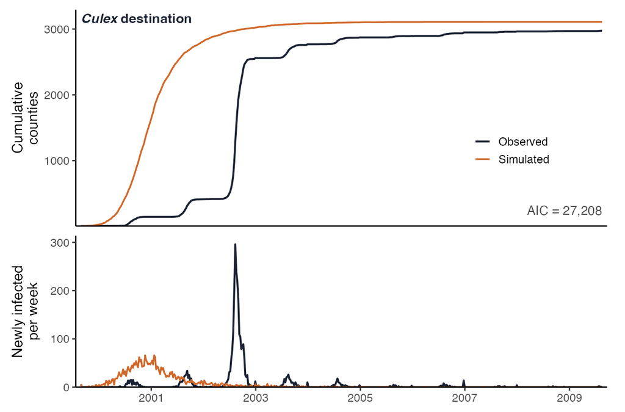

Also letting the destination depend on *Culex* suitability leaves the fit unchanged — AIC 27,208, essentially identical — so receptivity at the destination carries no signal.

## Hypothesis 2: Temperature-dependent transmission

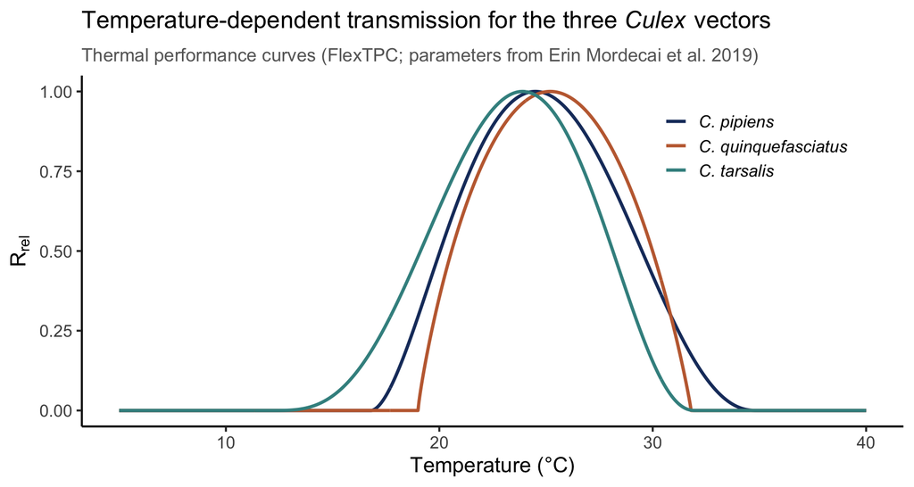

$$\lambda_{ij,t}=K\,[\,\textit{Culex}_i\,\mathcal{R}_{\text{rel}}(T_{i,t})\,]^{e^{s_1}}\,(\textit{Culex}_j)^{e^{d_1}}\,\textit{dist}_{ij}^{\,-e^{r_1}}$$

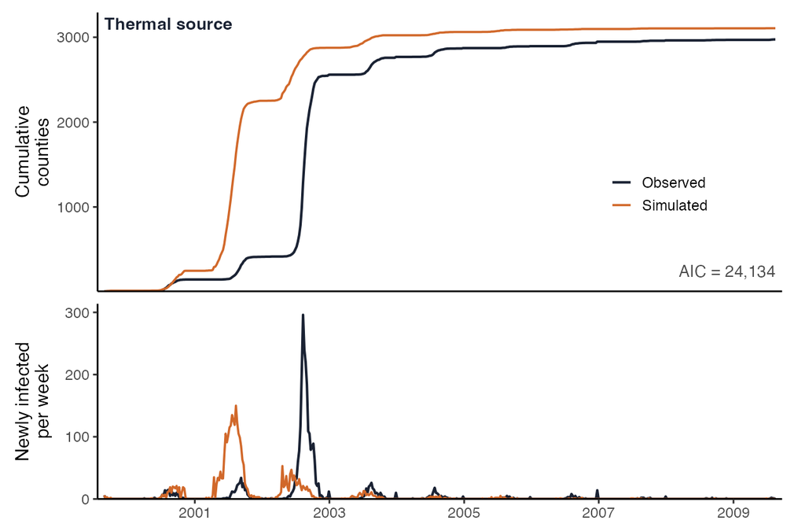

Scaling the source by the *Culex* thermal-performance term drops AIC to 24,134 and finally reproduces the seasonal steps — for no extra parameter.

## Hypothesis 3: Migratory bird movement gives the best model

$$\lambda_{ij,t}=K\,[\,\textit{Culex}_i\,\mathcal{R}_{\text{rel}}(T_{i,t})\,]^{e^{s_1}}\,(\textit{Culex}_j)^{e^{d_1}}\,(\,\textit{dist}_{ij}^{\,-e^{r_1}}+e^{r_2}\,\textit{bird}_{ij,t}\,)$$

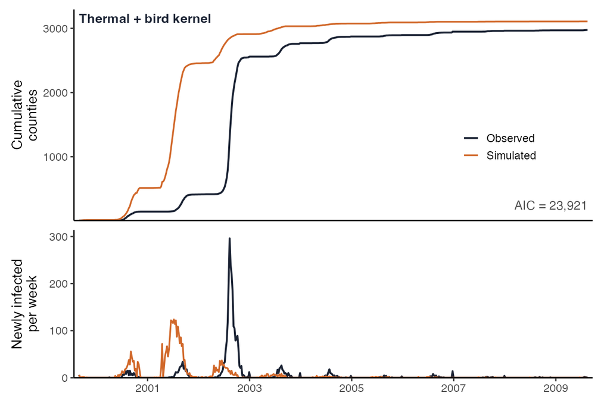

Adding weekly movement of 27 WNV-competent bird species to the redistribution kernel gives the best fit — AIC 23,921.

## The model reproduces the wave — and shows us what’s missing

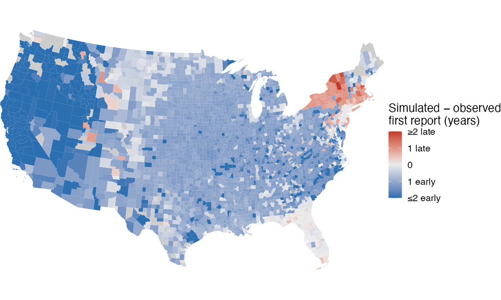

## Space sets the shape; temperature sets the timing

| Model | What it adds | k | NLL | AIC | Delta AIC |
| --- | --- | --- | --- | --- | --- |
| Homogeneous null | no space, no heterogeneity | 1 | 18215 | 36431 | 12510 |
| *Culex* source | + distance kernel + source suitability | 3 | 13600 | 27206 | 3284 |
| *Culex* destination | + destination suitability | 4 | 13600 | 27208 | 3286 |
| Thermal source | + temperature at source | 4 | 12063 | 24134 | 212 |
| Thermal + bird kernel | + bird migration | 5 | 11956 | 23921 | 0 |

## A general template for emerging diseases in complex landscapes

**The framework**

- Decompose spread into **source · redistribution · destination · observation**
- Fit **directly to surveillance** by likelihood
- Let **model comparison** find the minimal structure

**Where to intervene**

- **Source** — transmission control
- **Redistribution** — movement & vectors
- **Destination** — susceptibility

Heterogeneity is the rule.

## Acknowledgements

**Collaborators** — Eric Marty, JP Schmidt, Suzanne O’Regan

**Data & methods**

- Dispersal / S–R–D framework — Jongejans et al. 2015, *Theoretical Ecology* 8:207
- *Culex* suitability — Gorris et al. 2021, *Parasites & Vectors* 14:547
- Mosquito thermal biology — Mordecai et al. 2019, *Ecology Letters* 22:1690
- Bird abundances — Rosenberg et al. 2019, *Science* 366:120
- Bird movement (BirdFlow) — Fuentes et al. 2023, *Methods in Ecology and Evolution* 14:923
- Metapopulation inference — Li et al. 2024, *J. R. Soc. Interface* 21:20240217

# Backup

## Fitted parameters (Thermal + bird kernel)

| Parameter | Symbol | Estimate | Interpretation |
| --- | --- | --- | --- |
| Scale | $\alpha$ | $-4.24$ | $K = 10^{\alpha}$ |
| Source exponent | $e^{s_1}$ | $0.37$ | sub-linear in suitability × temperature |
| Distance exponent | $e^{r_1}$ | $1.63$ | power-law decay, heavy tail |
| Bird term | $e^{r_2}$ | $\approx 1.3\times10^{3}$ | migration flux added to kernel |
| Destination exponent | $e^{d_1}$ | $0.55$ | weak destination effect |

## The observation layer: right-censoring and detection

- We fit to **infected counties**; every not-yet-infected county contributes a **survival (zero-arrival)** term each week.
- The likelihood cleanly **separates process from observation**, so reporting can be modeled rather than assumed perfect.
- Extensions: explicit **detection probability** and **subsampling calibration** of the non-infected pool (as in the invasive-species version of this framework).

## The model sequence

- **Baseline gravity** distance kernel, suitability fixed at source · **Fitted source** free source suitability · **Fitted destination** free destination
- **Thermal source** temperature seasonality at source (best “for free”) · **Thermal both ends** temperature at destination (rejected)
- **Thermal + bird kernel** bird migration in the kernel (best overall)
- Each model adds one mechanism to the one before it — a nested sequence, so AIC differences are honest.